# Projekt 1 Faza 2

Dominik Ambroziak, Mateusz Jastrząb, Patrycja Matys, Kamil Wirtek

13 kwietnia 2016

### Wybranie grupy osób, które podchodziły do wielu stacji i spędzały przy nich więcej czasu niż przeciętny zwiedzający.

Pytanie: Czy istnieją eksponaty, które przyciągają uwagę właśnie tej grupy zwiedzających?

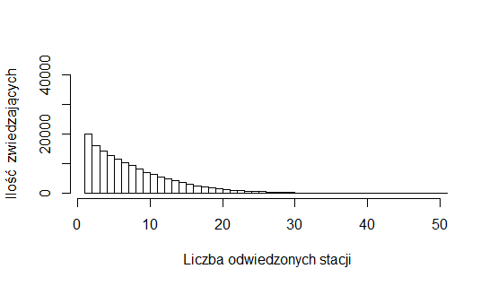

Grupę wszystkich visitorów podzieliliśmy początkowo na podgrupy:

-osoby, które odwiedziły jedną stację

-osoby, które odwiedziły od 2 do 5 stacji

-osoby, które odwiedziły od 6 do 10 stacji

-osoby, które odwiedziły co najmniej 11 stacji

Sprawdziliśmy ilość odwiedzin poszczególnych stacji w grupie wszystkich zwiedzających, jak i w poszczególnych podgrupach.

# Popularność stacji

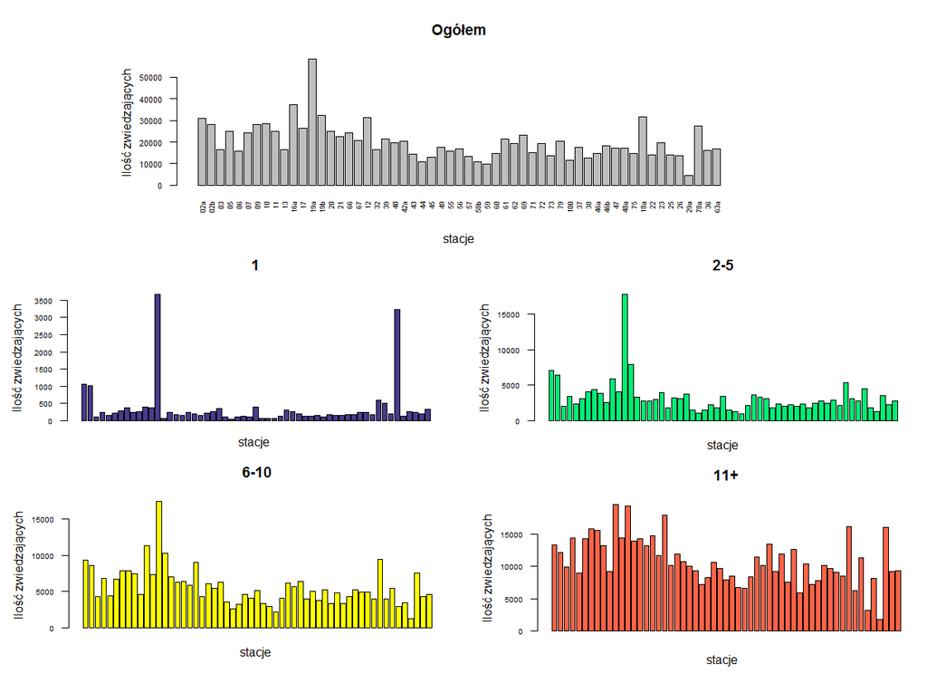

Można zauważyć, że gdy jakaś osoba odwiedziła tylko jedną stację, to jest to zazwyczaj stacja 19a lub stacja 25. Dla kolejnych grup zwiedzających 19a nadal jest jedną z najbardziej popularnych stacji, a stacja 25 w innych grupach nie jest już tak popularna. Można też zauważyć, że wraz ze wzrostem liczby odwiedzanych stacji przez jednego zwiedzającego, następuje upodabnianie się powyższych rozkładów do rozkładu jednostajnego.

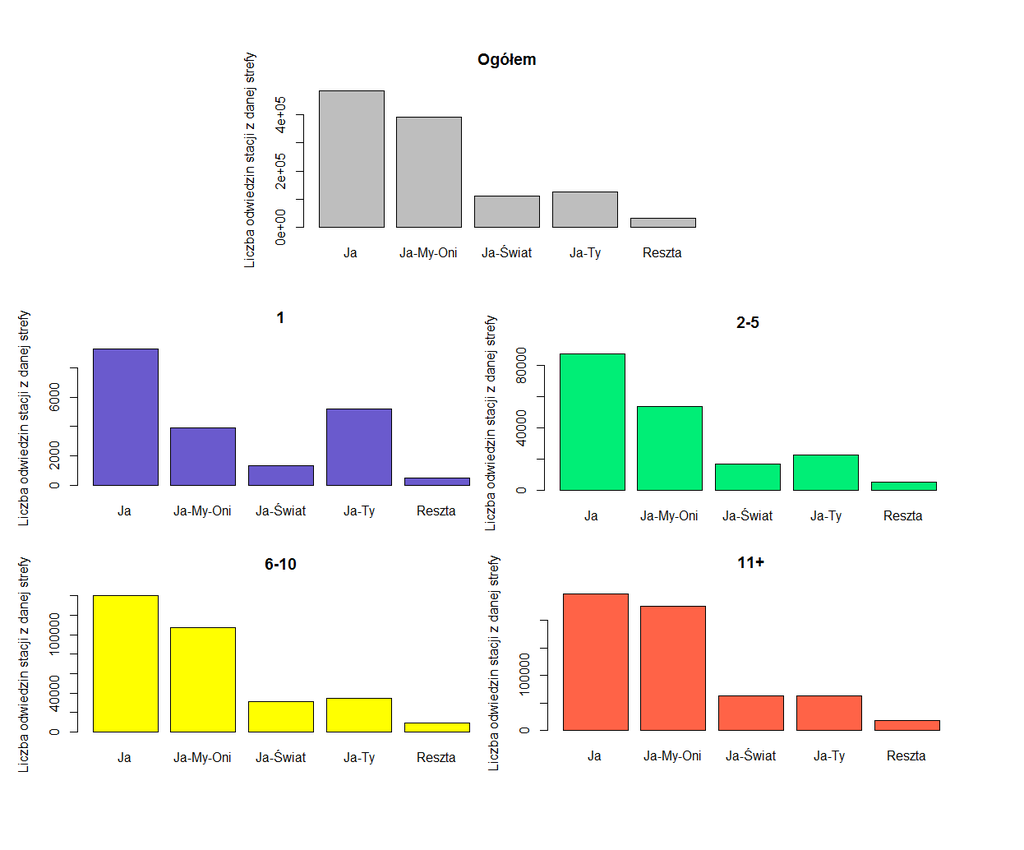

Patrząc na wykresy dla tych czterech grup możemy powiedzieć, że rozkład podejść do stacji z poszczególnych stref nie różni się zbytnio dla grup o różnych liczbach stacji zwiedzonych przez jednego zwiedzającego. Jedną z różnic jest większa popularność strefy Ja-Ty w grupie “1”, niż w pozostałych grupach. Przyczyną tej różnicy jest zaobserwowana wcześniej duża popularność, znajdującej się w tej strefie stacji 25. Można też zauważyć, że popularność strefy Ja-My-Oni rośnie, biorąc pod uwagę kolejne podgrupy.

Wracając do postawionego na początku pytania. Dalej pracowaliśmy już tylko na podgrupie 11+. Użyliśmy procedury kmeans() do podzielenia podgrup na trzy klastry, korzystając z danych z poniższej tabeli.

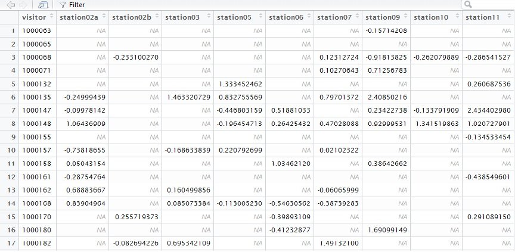

Niech:

w(v,s) - współczynnik czasu interakcji zwiedzającego v i stacji s,

t(v,s) - czas interakcji zwiedzającego v ze stacją s,

m(s) - średnia czasu interakcji dla stacji s,

sd(s) - odchylenie standardowe czasu interakcji dla stacji s,

wtedy:

w(v,s)=(t(v,s)-m(s))/sd(s)

Jak łatwo zauważyć, współczynnik dodatni oznacza, że dany zwiedzający był przy danej stacji dłużej niż przeciętny użytkownik tej stacji, ujemny - krócej. NA oznacza, że dany zwiedzający nie był przy tej stacji. Przed użyciem funkcji kmeans() wypełniliśmy pola z NA zerami.

Otrzymane klastry można scharakteryzować na wykresie współczynników centrów poszczególnych klastrów.

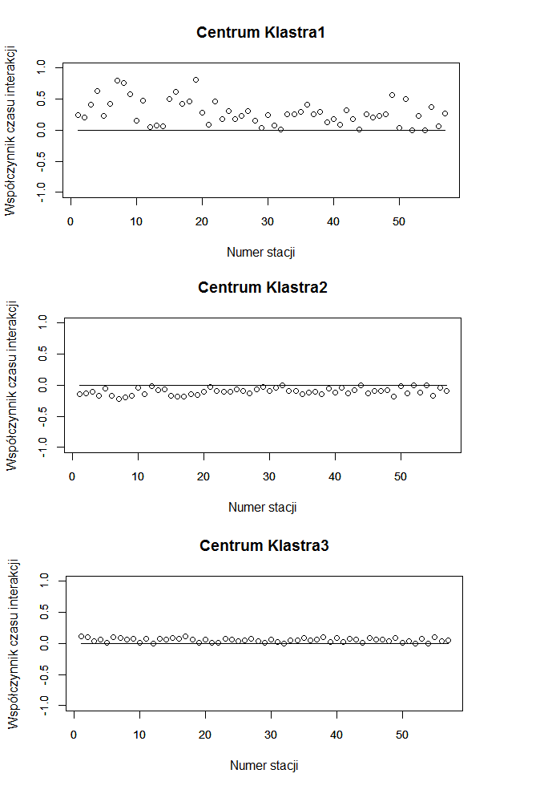

Klaster 1. Centrum tego klastra ma niemal wszystkie współczynniki dodatnie, część z tych współczynników jest większa od 0,5. Jest to zatem klaster składający się ze zwiedzających, którzy przy większości stacji, do których podchodzą są dłużej niż przeciętny zwiedzający.

Klaster 2. Współczynniki ujemne - osoby będące krócej przy eksponatach.

Klaster 3. Współczynniki są lekko dodatnie. Ten klaster pełni dla nas funkcję “separatora” klastra 1. oraz 2.. Trafiają tam osoby, o których nie można powiedzieć, że spędzają istotnie więcej, czy mniej czasu niż średnia. Lub osoby, które dla niektórych stacji przebywają krócej, a dla niektórych dłużej.

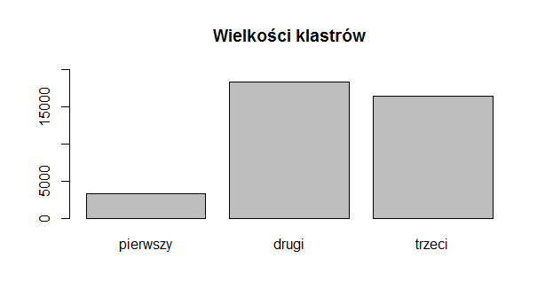

Sprawdzając teraz popularność wszystkich stacji, w poszczególnych klastrach znaleźliśmy stacje, które bardziej przyciągają wzrok osób z Klastra 1. niż z Klastra 2:

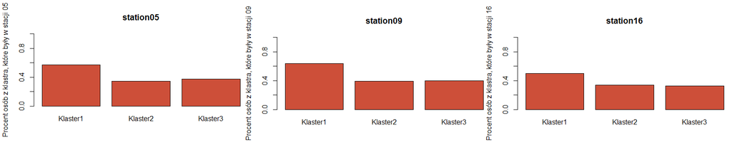

Stacje bardziej przyciągające wzrok osób z Klastra 2:

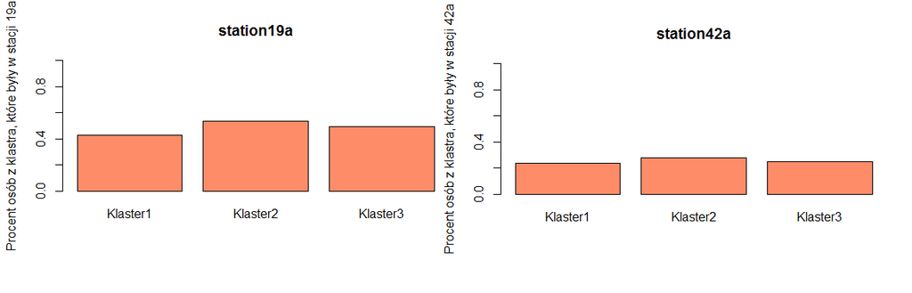

### Analiza segmentów, czy wśród odwiedzających można wyróżnić grupy typowych zwiedzających. Grupy można charakteryzować przez czas spędzany z eksponatem (dużo krótkich interakcji, szczegółowe zwiedzanie wielu eksponatów) zbiór odwiedzanych eksponatów (skupienie na wybranej grupie eksponatów) lub jeszcze inaczej.

Pytania:

1. Czy są grupy odwiedzających, preferujących pewien podzbiór eksponatów? Czy te grupy mają cechy charakterystyczne, inne niż podzbiór preferowanych eksponatów?
2. Czy preferowane eksponaty dla danej grupy mają cechy wspólne?

Będziemy pracować na danych zawierających informacje o 158.495 odwiedzających. Interesuje nas jedynie czy odwiedzający skorzystał ze stacji. Abstrahujemy od czasu korzystania ze stacji. W tym celu stworzyliśmy binarną macierz M, w której wiersze odpowiadają id odwiedzającego, a kolumny stacją. Przypisujemy wartość M[i,j]=1 jeśli odwiedzający i skorzystał ze stacji j, M[i,j]=0 w p.p.. Macierz wygląda następująco.

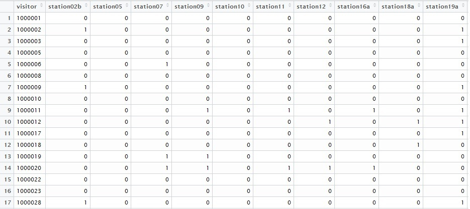

Dla takich danych dokonujemy podziału populacji na 5 grup za pomocą algorytmu k-średnich. Otrzymane grupy mają następującą liczności:

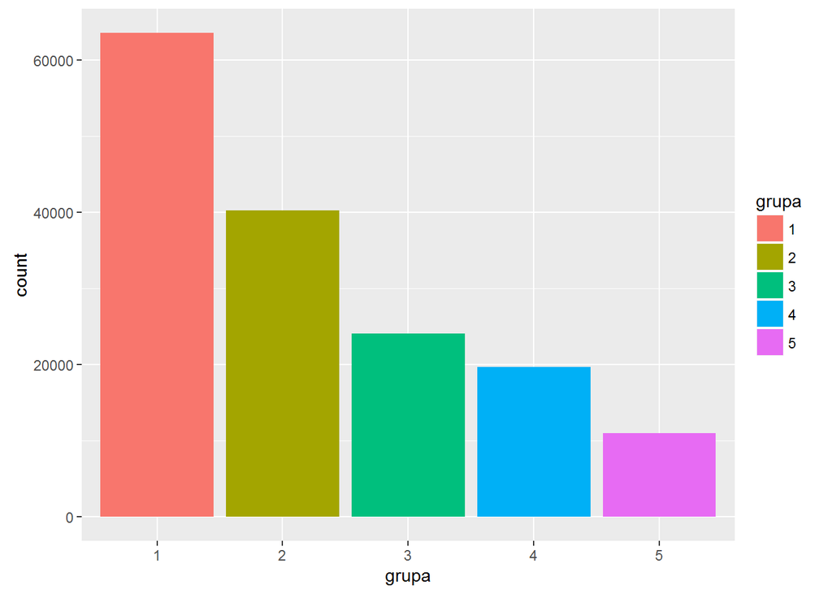

Dla każdego takiego podziału wybieramy do dalszego opisu 10 najbardziej i najmniej popularnych stacji. Szczegółowe informacje o nich jak i o grupach zawiera poniższa tabela:

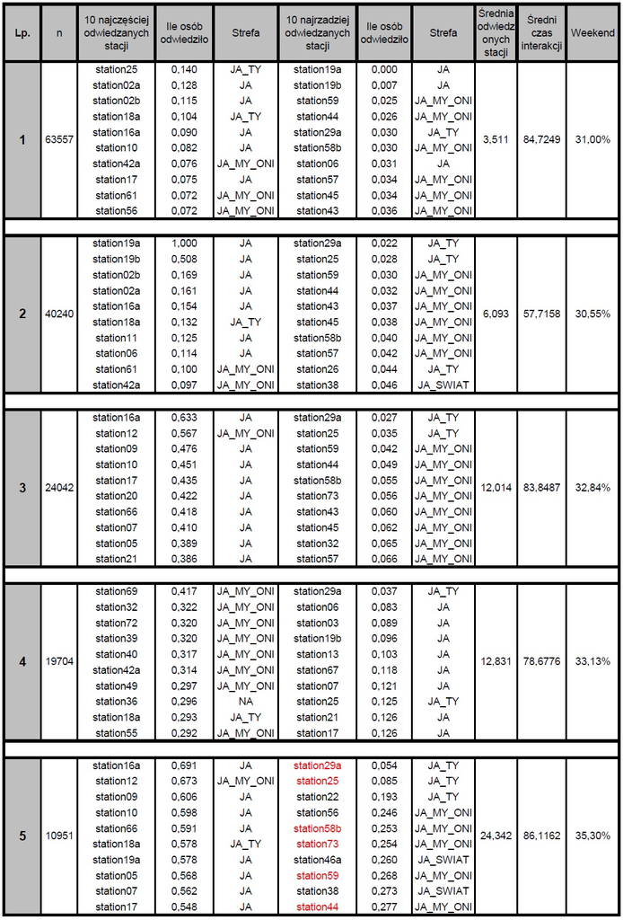

Kolumny powyższej tabeli zawierają następujące informacje:

-n o liczbie osób należących do grupy

-10 Najczęściej Odwiedzanych Stacji zawiera listę najbardziej popularnych stacji w grupie

-Ile Osób o procencie osób z grupy, którzy odwiedzili daną maszynę (szereguje stacje wg popularności)

-Strefa z jakiego obszaru tematycznego pochodzi stacja

-10 Najrzadziej Odwiedzanych Stacji zawiera listę najmniej popularnych stacji

-Weekend o procencie osób z grupy, którzy odwiedzili CNK w weekend

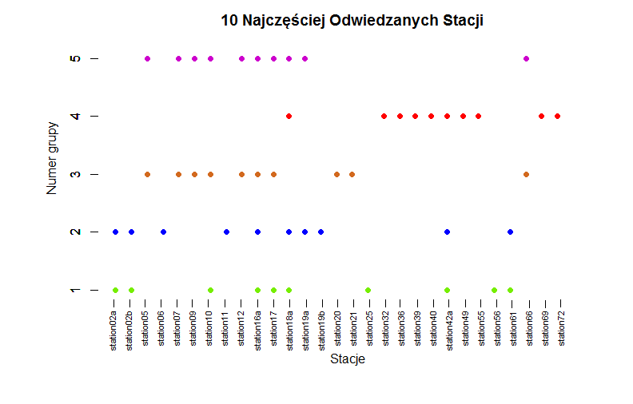

GRUPY PREFERENCJI Uwagi do danych. Zauważmy, że stacja 29a występuje dla wszystkich grup w zbiorze stacji najrzadziej odwiedzanych. Wynikać to może z długiego średniego czasu użytkowania stacji, który dla całej populacji wynosi 977,507 sekund. Zatem rzadkie korzystanie z tej stacji może wynikać z braku technicznej możliwości, a nie dlatego, że jest nieatrakcyjna. Celem jest przyjrzenie się najbardziej i najmniej popularnym stacją dla otrzymanych grup. Czy jest grupa odwiedzających mająca unikalny zbiór najczęściej użytkowanych stacji? Co nam mówią informację zawarte w tabeli?

1. Grupy 1 i 2 mają podobne zestawy stacji najbardziej i najmniej popularnych (6 wspólnych preferowanych stacji). Istotną różnicą dla nich są stacje 19a, 19b oraz 25. Stacja 25 jest najczęściej odwiedzana w grupie 1, natomiast dla grupy 25 jest drugą najrzadziej użytkowanych stacją(warto tu też nadmienić, że stacja 25 nie jest preferowana przez resztę grup. Pod tym względem grupa 1 jest unikatowa).
2. Grupa 3 posiada tylko 3 preferowane stacje należące grup 1 lub 2. Reszta jest unikatowa w porównaniu z tymi grupami. Natomiast lista stacji najmniej popularnych jest podobna (8 stacji należących do grup 1 lub 2).
3. Grupa 4 jest najbardziej unikatowa pod względem preferencji. Posiada 8 preferowanych stacji, którą nie należą do zbioru stacji preferowanych przez inne grupy. Podobnie jest ze stacjami najrzadziej odwiedzanymi (6 unikatowych stacji).
4. Grupa 5 ma podobny zbiór preferowanych stacji co grupa 3 (8 tych samych stacji). Wnioski. Wśród odwiedzających CNK można rozróżnić trzy zbiory eksponatów odwiedzanych przez różne grupy odwiedzających, pod względem stacji z których najczęściej korzystają. Pierwszy zbiór eksponatów to najbardziej popularne wspólne stacje dla grup 1 i 2, czyli stacje 02a, 02b, 16, 18, 42a, 61. Wymienione eksponaty należą do różnych stref ekspozycji „Regeneracja”. Drugi zbiór to najbardziej popularne stacje dla grupy 4. Pochodzą w zdecydowanej większości ze strefy JA MY ONI. Jest to cecha charakterystyczna tej grupy eksponatów. Trzeci zbiór to najbardziej popularne wspólne stacje dla grup 3 i 5, czyli stacje 16,12,09,10,17,66,07,05. Są to stacje ze strefy JA (oprócz stacji 12).

CECHY GRUP Celem jest opis otrzymanych grup. Chcemy sprawdzić, które cechy są jednorodne, a co odróżnia otrzymane grupy. Poniższy wykres prezentuje otrzymane grupy pod względem ilości odwiedzonych stacji i średniego czasu korzystania z maszyn.

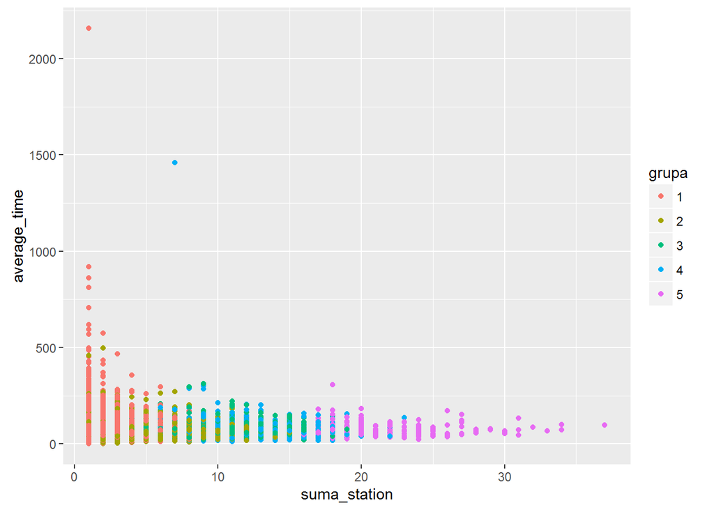

Powyższy wykres sugeruje, żeby bardziej szczegółowo przyjrzeć się rozkładowi liczby odwiedzanych stacji w rozróżnieniu na grupy.

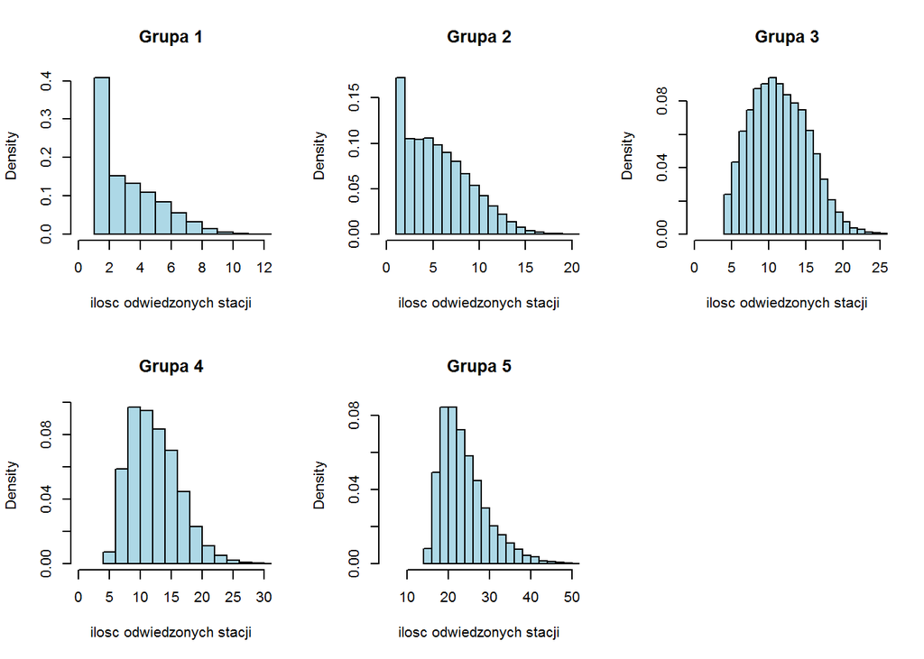

CHARAKTERYZACJA STACJI Teraz chcemy scharakteryzować najbardziej popularne stacje dla poszczególnych grup.  
Na początek rozważmy ich rozmieszczenie. Mapka poniżej prezentuje rozmieszczenie najbardziej popularnych stacji dla rozważanych grup.

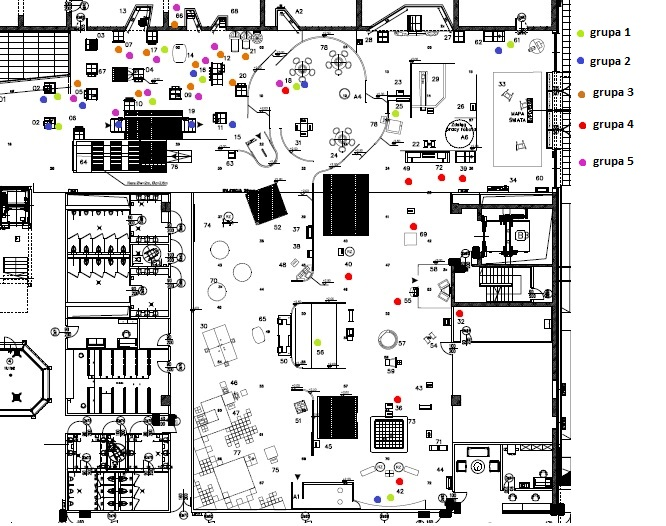